# Mean Vector and Covariance Matrix Estimation under Heavy Tails

Daniel P. Palomar and Rui ZHOU The Hong Kong University of Science and Technology (HKUST)

2019-11-12

# Installation

The package can be installed from [CRAN](https://CRAN.R-project.org/package=fitHeavyTail) or [GitHub](https://github.com/dppalomar/fitHeavyTail):

```r
# install stable version from CRAN
install.packages("fitHeavyTail")

# install development version from GitHub
devtools::install_github("dppalomar/fitHeavyTail")

# Getting help
library(fitHeavyTail)
help(package = "fitHeavyTail")
?fit_mvt
```

# Quick Start

To illustrate the simple usage of the package `fitHeavyTail`, let’s start by generating some multivariate data under a Student’s $t$ distribution with significant heavy tails ($\nu=4$):

```r
library(mvtnorm)  # package for multivariate t distribution
N <- 10   # number of variables
T <- 80   # number of observations
nu <- 4   # degrees of freedom for tail heavyness

set.seed(42)
mu <- rep(0, N)
U <- t(rmvnorm(n = round(0.3*N), sigma = 0.1*diag(N)))
Sigma <- U %*% t(U) + diag(N)  # covariance matrix with factor model structure
Sigma_scatter <- (nu-2)/nu * Sigma
X <- rmvt(n = T, delta = mu, sigma = Sigma_scatter, df = nu)  # generate data
```

We can first estimate the mean vector and covariance matrix via the traditional sample estimates (i.e., sample mean and sample covariance matrix):

```r
mu_sm <- colMeans(X)
Sigma_scm <- cov(X)
```

Then we can compute the robust estimates via the package `fitHeavyTail`:

```r
library(fitHeavyTail)
fitted <- fit_mvt(X)
```

We can now compute the estimation errors and see the big improvement:

```r
sum((mu_sm - mu)^2)
```

```
#> [1] 0.2857323
```

```r
sum((fitted$mu - mu)^2)
```

```
#> [1] 0.150424
```

```r
sum((Sigma_scm - Sigma)^2)
```

```
#> [1] 5.861138
```

```r
sum((fitted$cov - Sigma)^2)
```

```
#> [1] 2.957443
```

To get a visual idea of the robustness, we can plot the shapes of the covariance matrices (true and estimated ones) projected on two dimensions. Observe how the heavy-tailed estimation follows the true one more closely than the sample covariance matrix:

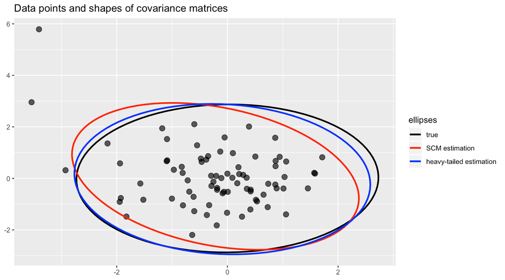

# Numerical Comparison with Existing Packages

In the following, we generate multivariate heavy-tailed Student’s $t$ distributed data and compare the performance of many different existing packages in terms of estimation accurary measured by the mean squared error (MSE) and cpu time.

```
#> Total execution time for 50 Monte-Carlo realizations:: 403.689 sec elapsed
```

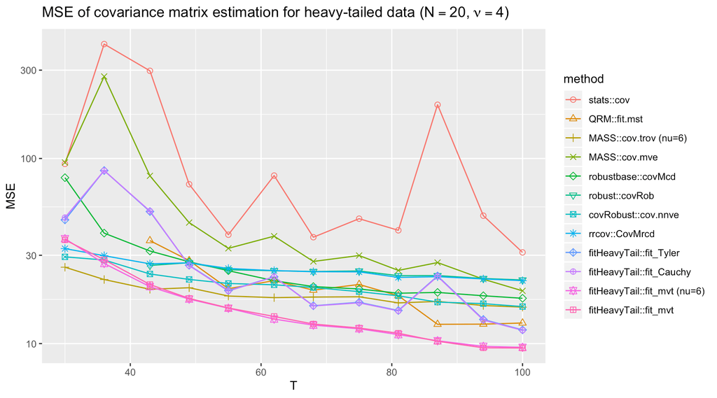

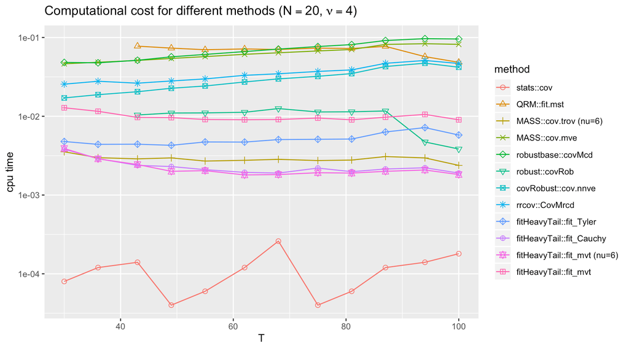

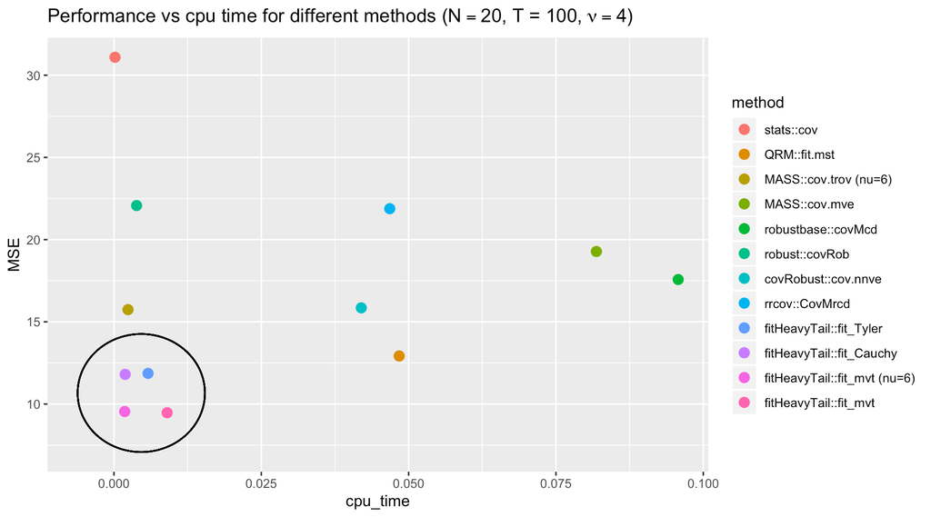

From the numerical results we can draw several observations:

- `stats:cov()` is the sample covariance matrix (SCM). As expected, it is not robust to heavy tails and has the worst estimation error although enjoyes the lowest computational cost. It is not acceptable for heavy-tailed distributions.
- `QRM::fit.mst()` assumes the data follows a multivariate $t$ distribution; it has one of the highest computational cost with a not-so-good estimation error.
- `MASS::cov.trob()` (with fixed `nu = 6`) assumes the data follows a multivariate $t$ distribution; it shows a good performance in terms of MSE and cpu time. It is probably the best choice among the benchmark existing packages (with the advantage that it comes preinstalled with base R in the package `MASS`).
- `MASS::cov.mve()` shows one of the worst performance in terms of both estimation error and computational cost.
- `robustbase::covMcd()` also shows one of the worst performance in terms of both estimation error and computational cost.
- `robust::covRob()` has a low computational cost but bad estimation error.
- `covRobust::cov.nnve()` shows a bad performance in terms of both estimatior error and cpu time.
- `fitHeavyTail::fit_Tyler()` normalizes the data (to get rid of the shape of the tail); it shows a very small estimation error with an acceptable computational cost.
- `fitHeavyTail::fit_Cauchy()` assumes a multivariate Cauchy distribution and depending on the ratio $N/T$ can be better or worse than the Tyler counterpart.
- `fitHeavyTail::fit_mvt()` assumes the data follows a multivariate $t$ distribution; it shows a small estimation error with accepteable computational cost.
- `fitHeavyTail::fit_mvt()` with fixed `nu = 6` seems to perform similar to `fitHeavyTail::fit_mvt()`, which also estimates `nu`, with a lower cpu time.
- Note the ellipse at the bottom left that embraces the best four methods: `fitHeavyTail::fit_Tyler()`, `fitHeavyTail::fit_Cauchy()`, `fitHeavyTail::fit_mvt()`, and `fitHeavyTail::fit_mvt()` with fixed `nu = 6`.

Concluding, the top choices seem to be (in order):

1. `fitHeavyTail::fit_mvt()` (either without fixing `nu` or with `nu = 6`),
2. `fitHeavyTail::fit_Tyler()` or `fitHeavyTail::fit_Cauchy()` depending on the ratio $N/T$, and
3. `MASS::cov.trob()` (with the advantage of being preinstalled with base R).

# Algorithms

In essence, all the algorithms are based on the maximum likelihood estimation (MLE) of some assumed distribution given the observed data. The difficulty comes from the fact that the optimal solution to such MLE formulations becomes too involved in the form of a fixed-point equation and the framework of Majorization-Minimization (MM) algorithms [1] becomes key to derive efficient algorithms.

In some cases, the probability distribution function becomes too complicated to manage directly (like the multivariate Student’s $t$ distribution) and it is necessary to resort to a hierarchical distribution that involves some latent variables. In order to deal with such hidden variables, one has to resort to the Expectation-Maximization (EM) algorithm, which interestingly is an instance of the MM algorithm.

In particular:

- The function `fitHeavyTail::fit_Tyler()` normalizes the centered samples, which then have an angular Gaussian distribution on the sphere, and performs an MLE based on the MM algorithm [2].
- The function `fitHeavyTail::fit_Cauchy()` assumes that the data follows a multivariate Cauchy distribution and performs an MLE based on the MM algorithm [3].
- The function `fitHeavyTail::fit_mvt()` assumes the the data follows a multivariate Student’s $t$ distribution and performs an MLE based on the EM algorithm [4]. This function can also incorporate a factor model structure on the covariance matrix, which requires a more sophisticated algorithm [5] (available in [arXiv](https://arxiv.org/abs/1909.12530)).

# References

[1] Y. Sun, P. Babu, and D. P. Palomar, “Majorization-minimization algorithms in signal processing, communications, and machine learning,” *IEEE Transactions on Signal Processing*, vol. 65, no. 3, pp. 794–816, 2017.

[2] Y. Sun, P. Babu, and D. P. Palomar, “Regularized Tyler’s scatter estimator: Existence, uniqueness, and algorithms,” *IEEE Trans. Signal Processing*, vol. 62, no. 19, pp. 5143–5156, 2014.

[3] Y. Sun, P. Babu, and D. P. Palomar, “Regularized robust estimation of mean and covariance matrix under heavy-tailed distributions,” *IEEE Trans. Signal Processing*, vol. 63, no. 12, pp. 3096–3109, 2015.

[4] C. Liu and D. B. Rubin, “ML estimation of the t-distribution using EM and its extensions, ECM and ECME,” *Statistica Sinica*, vol. 5, pp. 19–39, 1995.

[5] R. Zhou, J. Liu, S. Kumar, and D. P. Palomar, “Robust factor analysis parameter estimation,” *Lecture Notes in Computer Science (LNCS)*, 2019.